# Project

Harsha

05/6/2024

## Introduction

Here I try to understand how much of an effect sex has in explaining the variability in the number of car accidents during the holiday season when aggregated at the state level. The holidays I examined were Christmas, Thanksgiving, and 4th of July since these are major US holidays. I defined Christmas season from December 16 - 27 and Thanksgiving as November 19-30. The data was provided by the NHTSA for the years 1996 through 2016.

First I will see if the data is appropriate for this type of analysis. More specifically, we want to check if the epsilon is constant in the following linear model: $Number Of accidents = μ_{sex} + epsilon$

If the residuals varied across each sex, we could not explain how much of the variability in number of accidents can be explained by the fitted mean sex-grouped accidents. We want to know that we can attribute some of the variability to the difference in average accidents for each sex.

To understand if our ε are constant, we create a pooled QQ plot and a S-L plot.

## Analysis

### Import apporpiate libraries

```r
library(ggplot2)
library(dplyr)
library(tidyr)
library(lubridate)
```

### Data Mining

```r
df <- readRDS("farsp.RDS") #load accident data
alcohol <- read.csv("alcohol.csv") #load alcohol data
state <- read.csv("state_code.csv")

#Create df for accidents grouped by state and sex
df1 <- df %>%
  mutate( Date = ymd_hm( paste(year, month, day,hour, minute, sep="-")),
          sex = case_when(sex == 1 ~ "Male",
                          sex == 2 ~ "Female",
                          sex == 8 ~ "not reported",
                          sex ==  9 ~ "unkown"),
          Holiday= case_when(mday(Date) > 15 & mday(Date) < 28 &
                                               month(Date)==12 ~ "Christmas",
                              mday(Date) > 18 & mday(Date) < 31 &
                                              month(Date)==11 ~ "Thanksgiving",
                            mday(Date) == 4 & month(Date) == 7 ~
                              "Independence Day",
          TRUE ~ "Not holiday")) %>%
  left_join(alcohol, by = c("drinking" = "alcohol")) %>%
     left_join(state, by = c("state" = "state_code")) %>%
  filter(drinking == 0 | drinking == 1, sex  == "Male" | sex == "Female", Holiday !="Not holiday") %>%
  group_by(state_name,sex) %>%
  summarise("Number of accidents" = n())
```

### Pooled residuals q-q plot

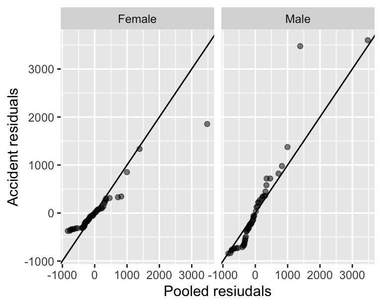

```r
df2 <- df1 %>%
  group_by(sex)  %>%
  mutate(`Number of accidents` = `Number of accidents` -
           mean(`Number of accidents`)) %>%   #get resiudals by sex
  arrange(`Number of accidents`)  %>%
  mutate(f.val    = (row_number() - 0.5) / n())  %>% #create percentiles
  ungroup()  %>% #ungroup to get pooled residuals for all of data
  mutate(Pooled.res = quantile(`Number of accidents`, probs = f.val, na.rm = TRUE))  %>%
  select(sex, `Number of accidents`, Pooled.res)

#Graph pooled qq plot for each sex
ggplot(df2, aes(y = `Number of accidents`, x = Pooled.res)) +
  geom_point(alpha = 0.5) +
  geom_abline(intercept = 0, slope = 1) +
  ylab("Accident residuals")+ xlab("Pooled resiudals")+
  facet_wrap(~ sex, nrow = 1)
```

### S-L plot

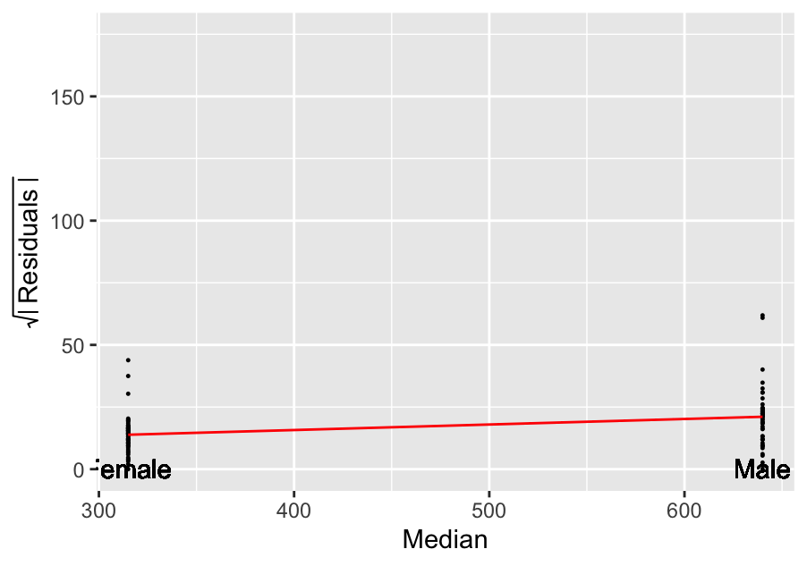

```r
#Create dataframe for s-l plot
sl <- df1 %>%
  group_by(sex) %>%
  mutate( Median = median(`Number of accidents`), #get median for accidents
          Residuals =  sqrt(abs(`Number of accidents` - Median)))  %>%
  ungroup()

#Create s-l plot
ggplot(sl, aes(x = Median, y = Residuals)) + #define x and y for s-l plot
  geom_jitter(alpha = 1, width = 0.0002, height = 0, cex = 0.2) +
  stat_summary(fun = median, geom = "line", col = "red") +
  ylab(expression(sqrt( abs( " Residuals "))))+
  geom_text( aes(x = Median, y = 0.2, label = sex)) +
  coord_cartesian(ylim = c(0, 175)) #limit y axis
```

Now we see that there is a increase in the spread of number of accidents as a function of median accidents across the groups. A increasing monotonic spread is apparent in this dataset. Hence, the spread or epsilon is not constant, so we can not discern how much sex explains the difference is number of accidents. We are going to have to transform this data.

### Transforming the Data

First, let’s try taking a box cox transformation on our y vairbale of number of accidents. I tried performing a log transformation as well, but the conditions of constant resiudals and equal spreads in the residuals across the sex was not satisfied. Again, we want our epsilon in the model to be constant.

### Determine power to use in box cox transformation

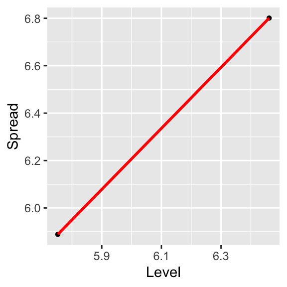

```r
# Create s-l table
df.sl <- df1 %>%
  group_by(sex)  %>%
  summarise (level  = log(median(`Number of accidents`)),
                IQR = IQR(`Number of accidents`),
             spread = log(IQR))


# Plot spread vs median
ggplot(df.sl, aes(x = level, y = spread)) +
  geom_point(shape = 16) +  # Scatter plot with shape 16
  geom_smooth(method = "lm", formula = y ~ x, se = FALSE, color = "red") + #line
  labs(x = "Level", y = "Spread") # Label axes
```

```r
#Create model
M <- MASS::rlm(spread ~ level, df.sl)
coef(M)
```

```
## (Intercept)       level
##   -1.510627    1.286295
```

```r
1 - coef(M)[2] #determine power to use
```

```
##      level
## -0.2862949
```

So the suggested power is 1 - 1.286295 or -0.2862949 (-0.29). We choose the Box-Cox method over the Tukey method because the power is negative and we want to preserve the same direction of the data.

### Boxcox Transformation and accompanying plots

```r
#define Box Cox transformation
BC <- function(x, p = 0) {
  if(p == 0) {
    z <- log(x)
  } else {
    z <- (x^p - 1)/p
  }
  return(z)
}

#Transform response vairable
df1$re.AccidentsNumber <- BC(df1$`Number of accidents`, -0.2862949 )
```

#### Pooled QQ plot

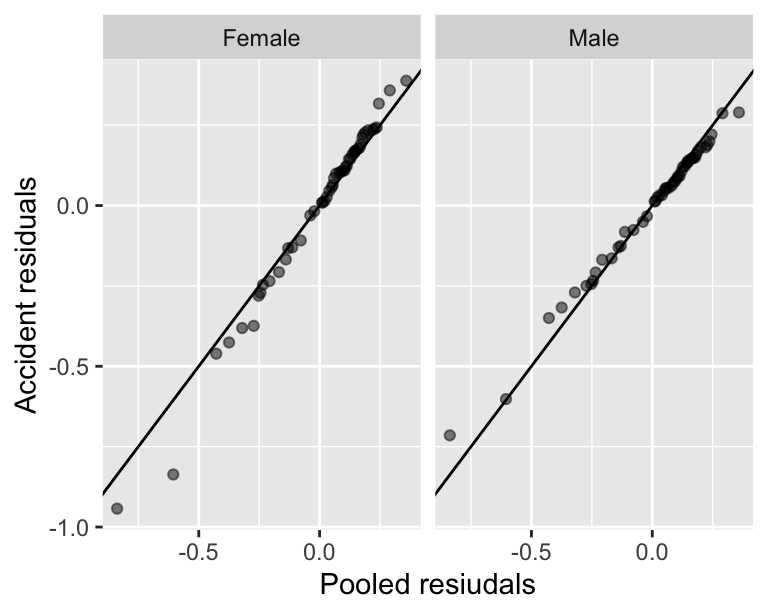

```r
#Create QQ plot df
df4 <- df1 %>%
  group_by(sex)  %>%
  mutate(`re.AccidentsNumber`= `re.AccidentsNumber` - mean(`re.AccidentsNumber`)) %>% #normalize accident number
  arrange(`re.AccidentsNumber`)  %>%
  mutate(f.val = (row_number() - 0.5) / n())  %>% #create percentiles
  ungroup()  %>% #ungroup to get pooled residuals for all of data
  mutate(Pooled.res = quantile(`re.AccidentsNumber`, probs = f.val,
                               na.rm = TRUE))  %>%
  select(sex, `re.AccidentsNumber`, Pooled.res)

##QQ plot
ggplot(df4, aes(y = `re.AccidentsNumber`, x = Pooled.res)) + geom_point(alpha = 0.5) + geom_abline(intercept = 0, slope = 1) +
  ylab("Accident residuals")+ xlab("Pooled resiudals")+
              facet_wrap(~ sex, nrow = 1) #separate by sex
```

Each of the sexes seem to have similar spreads. There is more deviation for lower values in the female group, which may indicate some outliers. But the core of the data (within -1 to 1 standard deviations) seem to fall on the 1:1 line consistently well. For the most part the majority of the points on both sexes are near or on the line, so we will characterize them as having similar spreads. However, we can confirm this further with the spread-level plot below. We will see if the spread in residuals depends on the median number of accidents by sex.

#### S-L Plot

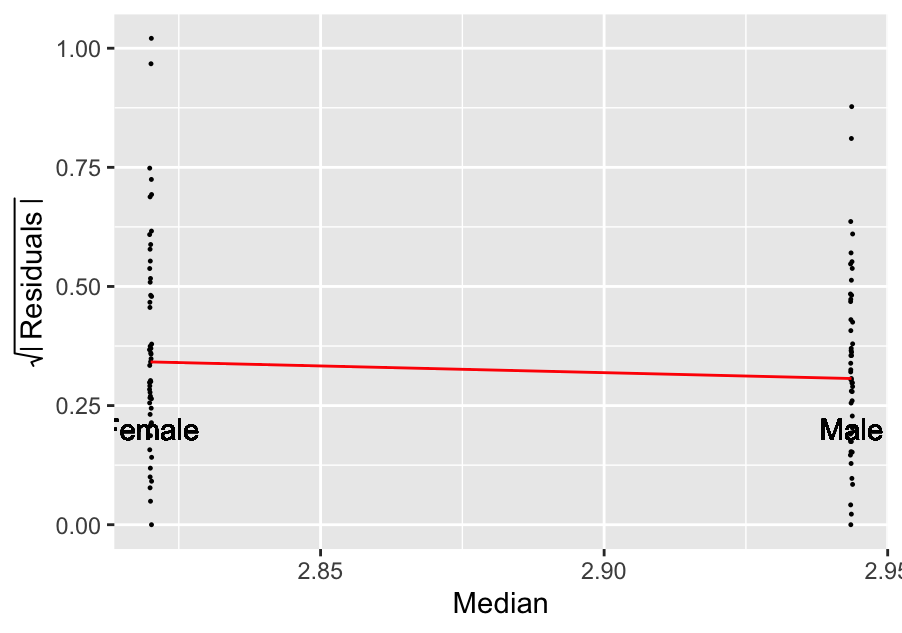

```r
##SL dataframe
sl3 <- df1 %>%
  group_by(sex) %>%
  mutate( Median = median(`re.AccidentsNumber`), #get median of each sex
          Residuals =  sqrt(abs(`re.AccidentsNumber` - Median)))  %>%
  ungroup()

##SL plot
ggplot(sl3, aes(x = Median, y = Residuals)) +
  geom_jitter(alpha = 1, width = 0.0002, height = 0, cex = 0.2) +
  stat_summary(fun = median, geom = "line", col = "red") +
  ylab(expression(sqrt( abs( " Residuals "))))+
  geom_text( aes(x = Median, y = 0.2, label = sex))
```

Now we see that there is a slight decrease in the spread of number of accidents as a function of median number of accidents. However, the decrease is very slight. For the most part, the spread in residuals is constant across both the medians for each group.

We can now assess the influence the sex has in explaining the accident spreads since we can now treat the residuals/epsilon in our model of $Number Of accidents^{-0.2862949} = μ_{sex}~ + epsilon$ as being constant. We use an R-F plot to quantify how much of the vairability is explained below.

#### R-f on boxcox data

[figure not shown]

```r
rf2 <- df1 %>%   # Normalize values to global mean
  mutate(norm = re.AccidentsNumber - mean(re.AccidentsNumber))%>%
  group_by(sex) %>%
  mutate( Residuals1  = norm - mean(norm, na.rm = TRUE), # Extract group residuals
          `Fitted values` = mean(norm, na.rm = TRUE)) %>% # Extract group means
  ungroup() %>%
  select(Residuals1, `Fitted values`) %>%
  pivot_longer( names_to = "type", values_to = "Values",
                cols = everything()) %>%
  group_by(type) %>%
  arrange(Values) %>%
  mutate( fval= (row_number()-0.5)/ n()) #calculate f val

#Overlayed R-F spread plot
ggplot(rf2, aes(x = fval, y = Values, col = type)) +
  geom_point(alpha = 0.3, cex = 1.5) +
  xlab("f-value") + ylab("Values") + ggtitle("R-F spread plot")
```

Above is a R-f spread plot for the transformed Number of Accidents. Each of the red fitted chunks represent the normalized average number of accidents for male and female, while the blue dots is the overall residuals.

#### Boxplot on transformed and untransformed data

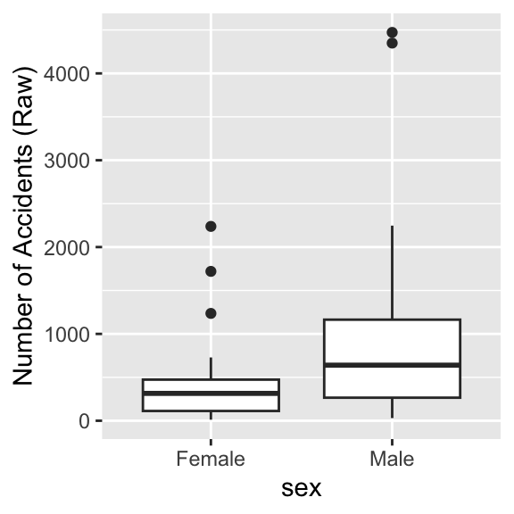

```r
ggplot(df1) + aes(x = sex, y = `Number of accidents`) + geom_boxplot() +ylab("Number of Accidents (Raw)")
```

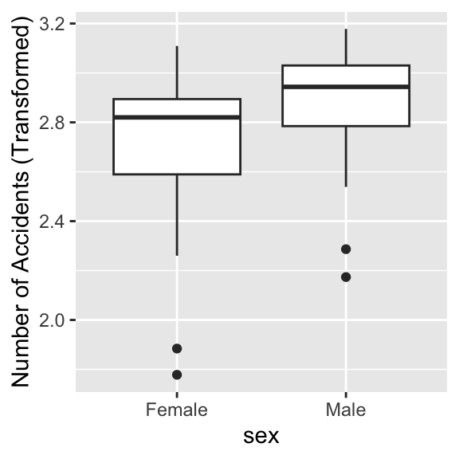

```r
ggplot(df1) + aes(x = sex, y = re.AccidentsNumber) + geom_boxplot() + ylab("Number of Accidents (Transformed)")
```

The boxplot on the rawdata shows that about 50% of the distrubution of male accidents by state are above that of the female distrubution for number of accidents (ignoring outliers). This indicates that there was a lot of difference in the number of accidents by sex to begin with. The tranformed boxplot also has males generally having more accidents. Our R-F plot supports this observation.

I am curious why males tend to have more accidents than females. I suspect that males tend to be drinking when they have accidents, while either females drink less or none at all. So, I want to compare the percentage of females that drink alcohol to that of males.

### Alcohol and Sex Percentage

#### Create Dataframes

```r
df5 <- df %>%
  mutate( Date = ymd_hm( paste(year, month, day,hour, minute, sep="-")),
          sex = case_when(sex == 1 ~ "Male",
                          sex == 2 ~ "Female",
                          sex == 8 ~ "not reported",
                          sex ==  9 ~ "unkown"),
          Holiday= case_when(mday(Date) > 15 & mday(Date) < 28 &
                                               month(Date)==12 ~ "Christmas",
                              mday(Date) > 18 & mday(Date) < 31 &
                                              month(Date)==11 ~ "Thanksgiving",
                            mday(Date) == 4 & month(Date) == 7 ~
                              "Independence Day",
          TRUE ~ "Not holiday")) %>%
  left_join(alcohol, by = c("drinking" = "alcohol")) %>%
     left_join(state, by = c("state" = "state_code")) #dataframe without count
```

```r
#Create df for number of accidents by sex and alcohol content
two_way_count <- df5 %>%
  filter(drinking == 0 | drinking == 1, sex  == "Male" | sex == "Female",           Holiday != "Not holiday")  %>%
  group_by(sex, description) %>%
  summarise(count = n())
```

### Boxplot of number of accidents according to holiday type

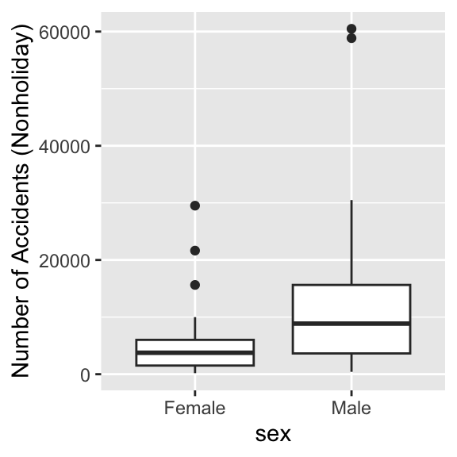

```r
#Dataframe for accidents by state and sex for nonholidays
df6 <- df5 %>%
  filter(drinking == 0 | drinking == 1, sex  == "Male" | sex == "Female",           Holiday == "Not holiday") %>%
  group_by(state_name,sex) %>%
  summarise("Number of accidents" = n())

#Nonholidays plot
ggplot(df6) + aes(x = sex, y = `Number of accidents`) + geom_boxplot() + ylab("Number of Accidents (Nonholiday)")
```

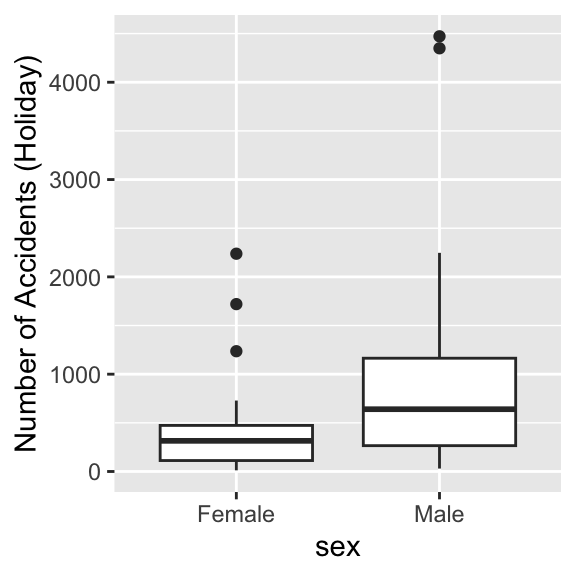

```r
#Holidays plot
ggplot(df1) + aes(x = sex, y = `Number of accidents`) + geom_boxplot() + ylab("Number of Accidents (Holiday)")
```

## Discussion

From the boxplots above, we can see that the distribution of number of accidents by sex when aggregated by state have roughly the same distribution shape in both holidays and non holidays. The only difference is that in non holidays the highest point is around 60,000 while that for holidays is 4,500. These distributions are nearly identical in shape but the scales vary very much. The nonholiday time period has generally more accidents, but the shape of the distributions are similar in both time periods. This indicates that if we ran another analysis on the nonholiday period, we may also have to perform a box cox transformation since the raw distribution has a similar shape as the holiday one. Of course, we would need to vertify this to be sure. For simplicity, I do not perform this here.

In conclusion, we learned that we can create a model of the form $Number Of accidents^{-0.2862949} = μ_{sex} + epsilon$, where sex explains a lot of the vairability for the number of accidents (transformed).

## References

R Core Team (2024). *R: A Language and Environment for Statistical Computing*. R Foundation for Statistical Computing, Vienna, Austria. https://www.R-project.org/.

Wickham H, François R, Henry L, Müller K, Vaughan D (2023). *dplyr: A Grammar of Data Manipulation*. R package version 1.1.4, https://CRAN.R-project.org/package=dplyr.

H. Wickham. ggplot2: Elegant Graphics for Data Analysis. Springer-Verlag New York, 2016.

Wickham H, Vaughan D, Girlich M (2024). *tidyr: Tidy Messy Data*. R package version 1.3.1, https://CRAN.R-project.org/package=tidyr.

Garrett Grolemund, Hadley Wickham (2011). Dates and Times Made Easy with lubridate. Journal of Statistical Software, 40(3), 1-25. URL https://www.jstatsoft.org/v40/i03/.